# Assignment05

Guillermo

2022-07-15

Assignment05______________________________________________________________________________

2. Question 2 from assignment02:

Assign a variable name to each of the following and use (R)Python to identify the data type of each variable: 2 2.0 10j 2 Cool for School True

```r
Two <- 2
class(Two)
```

```
## [1] "numeric"
```

```r
TwoPointO <- 2.0
class(TwoPointO)
```

```
## [1] "numeric"
```

```r
TenJ <- "10j" # Did you try without the quotes?
class(TenJ)
```

```
## [1] "character"
```

```r
Phrase <- "2 cool for school"
class(Phrase)
```

```
## [1] "character"
```

```r
ThisIs <- TRUE # Did you it as True?
class(ThisIs)
```

```
## [1] "logical"
```

Question 5 from assignment05

This question was part of an in-person interview where you were expected to write the code on a board: “Design a function in which I can input a value, when I input the value, it returns the 4 possible outputs”: - If it is a multiple of 3 return the string “foo” - If it is a multiple of 5 return the string “bar” - If it is a multiple of 15 return the string “foobar” - If it does not satisfy any of those, return the string “Not a multiple of 3, 5, or 15”

```r
FoobarFunction <- function(A){

# FoobarFunction will inform you if the entered value is a multiple of 3, 5, or 15.
# It will display "foo", "bar", and "foobar" respectively.
# Precondition: This function will not work by typing in strings.
#
# Examples below:
#>>> FoobarFunction(30)
# [1] "foobar"
#>>> FoobarFunction(20)
# [1] "bar"
# >>> FoobarFunction(6)
# [1] "foo"
#>>> FoobarFunction(17)
# [1] "Not a multiple of 3, 5, or 15"
#>>> FoobarFunction(six)
# Error in FoobarFunction(six) : object 'six' not found

if  ((as.integer(A/15)) == A/15) {
return("foobar")
}
if ((as.integer(A/3)) == A/3) {
return("foo")
}
if ((as.integer(A/5)) == A/5) {
return("bar")
}

else {
return("Not a multiple of 3, 5, or 15")
}
}


# Missing testing cases. Should also have a catch within function to catch strings. I see the preconditions, but it is needed within the function (-4)

# FoobarFunction("cat") commented out to allow document run
FoobarFunction(90)
```

```
## [1] "foobar"
```

```r
FoobarFunction(20)
```

```
## [1] "bar"
```

```r
FoobarFunction(9)
```

```
## [1] "foo"
```

3. Bring in dataset “swiss” (details about dataset here: swiss function - RDocumentation)

```r
Data <- swiss
```

4. Provide the summary statistics for all the variables

```r
summary(swiss)
```

```
##    Fertility      Agriculture     Examination      Education
##  Min.   :35.00   Min.   : 1.20   Min.   : 3.00   Min.   : 1.00
##  1st Qu.:64.70   1st Qu.:35.90   1st Qu.:12.00   1st Qu.: 6.00
##  Median :70.40   Median :54.10   Median :16.00   Median : 8.00
##  Mean   :70.14   Mean   :50.66   Mean   :16.49   Mean   :10.98
##  3rd Qu.:78.45   3rd Qu.:67.65   3rd Qu.:22.00   3rd Qu.:12.00
##  Max.   :92.50   Max.   :89.70   Max.   :37.00   Max.   :53.00
##     Catholic       Infant.Mortality
##  Min.   :  2.150   Min.   :10.80
##  1st Qu.:  5.195   1st Qu.:18.15
##  Median : 15.140   Median :20.00
##  Mean   : 41.144   Mean   :19.94
##  3rd Qu.: 93.125   3rd Qu.:21.70
##  Max.   :100.000   Max.   :26.60
```

```r
# Needs spread metrics as well (sd or variance) (-5)
```

5. Which province has the highest percent of males involved in agriculture as their occupation

```r
max(Data[c("Agriculture")])
```

```
## [1] 89.7
```

```r
which.max(Data[,2])
```

```
## [1] 33
```

```r
row.names(Data[33,])
```

```
## [1] "Herens"
```

```r
Province <- row.names(Data[33,])
```

6. Provide the correlation values bewteen all the variables

```r
cor(Data)
```

```
##                   Fertility Agriculture Examination   Education   Catholic
## Fertility         1.0000000  0.35307918  -0.6458827 -0.66378886  0.4636847
## Agriculture       0.3530792  1.00000000  -0.6865422 -0.63952252  0.4010951
## Examination      -0.6458827 -0.68654221   1.0000000  0.69841530 -0.5727418
## Education        -0.6637889 -0.63952252   0.6984153  1.00000000 -0.1538589
## Catholic          0.4636847  0.40109505  -0.5727418 -0.15385892  1.0000000
## Infant.Mortality  0.4165560 -0.06085861  -0.1140216 -0.09932185  0.1754959
##                  Infant.Mortality
## Fertility              0.41655603
## Agriculture           -0.06085861
## Examination           -0.11402160
## Education             -0.09932185
## Catholic               0.17549591
## Infant.Mortality       1.00000000
```

7. Plot the relationship between fertility and education where fertility is on the y-axis and education is on the x-axis

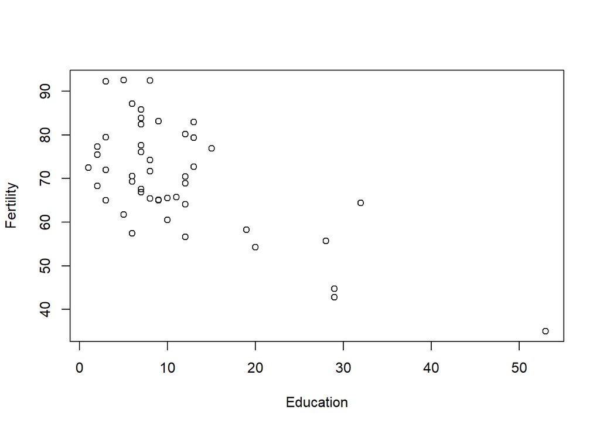

```r
Fertility <- Data$Fertility
Education <- Data$Education

plot(Education, Fertility)
```

8. Provide a histogram of the % of individuals that were catholic

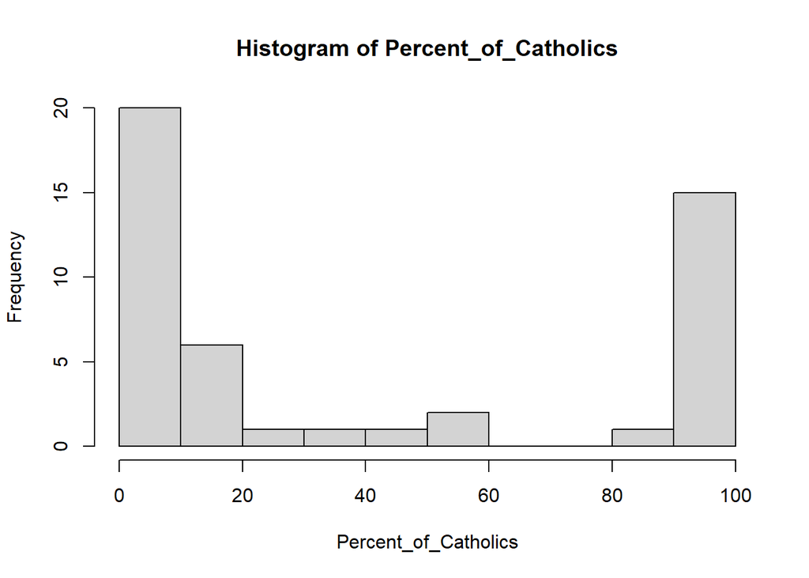

```r
Percent_of_Catholics <- Data$Catholic

hist(Percent_of_Catholics)
```